# Sesion 09: Clasificacion no supervisada

Juan Carlos Martinez-Ovando

Primavera 2017

# Introduccion

El agrupamiento de datos (a.k.a. *clasificacion no supervisada* o *clustering*) nos permite comprender mejor cómo una muestra puede estar compuesta de subgrupos distintos dados un conjunto de variables, *cuando la definición de los grupos y su asociación con los datos no ha sido develada con anterioridad*.

Paquetes que utilizaremos en la sesión:

```
install.packages("mclust")
install.packages("kknn")
install.packages("caret")
```

`dendroCol` es una funcion para colorear grupos:

```r
dendroCol <- function(dend=dend, keys=keys,
                      xPar="edgePar", bgr="red", fgr="blue",
                      pch=20, lwd=1, ...){
  if(is.leaf(dend)){
    myattr <- attributes(dend)
    if(length(which(keys==myattr$label))==1){
      attr(dend, xPar) <- c(myattr$edgePar,
                            list(lab.col=fgr, col=fgr,
                                 pch=pch, lwd=lwd))
      # attr(dend, xPar) <- c(attr$edgePar, list(lab.col=fgr, col=fgr, pch=pch))
    }else{
      attr(dend, xPar) <- c(myattr$edgePar, list(lab.col=bgr, col=bgr, pch=pch, lwd=lwd))
    }
    }
  return(dend)
}
```

## I. Basados en distancias

### I-a) K-Means

Observe que en `K-Means`, requerimos la definición de: + La función de distancia + La función media + El número de centroides $K$

**Nota:** `K-Means` es $O(nrk)$, donde $n$ es el número de puntos, $r$ es el número de rondas y $k$ el número de centroides.

El resultado de cada ronda es indeterminista. Las prácticas habituales consiste en ejecutar varias rondas de `K-Means` y elegir el resultado de la mejor ronda. La mejor ronda es aquella que minimiza la distancia media de cada punto a su centroide asignado.

Veamos un ejemplo con los datos `iris` de plantas que iniciamos a estudiar en la sesión de *clasificación supervisda*.

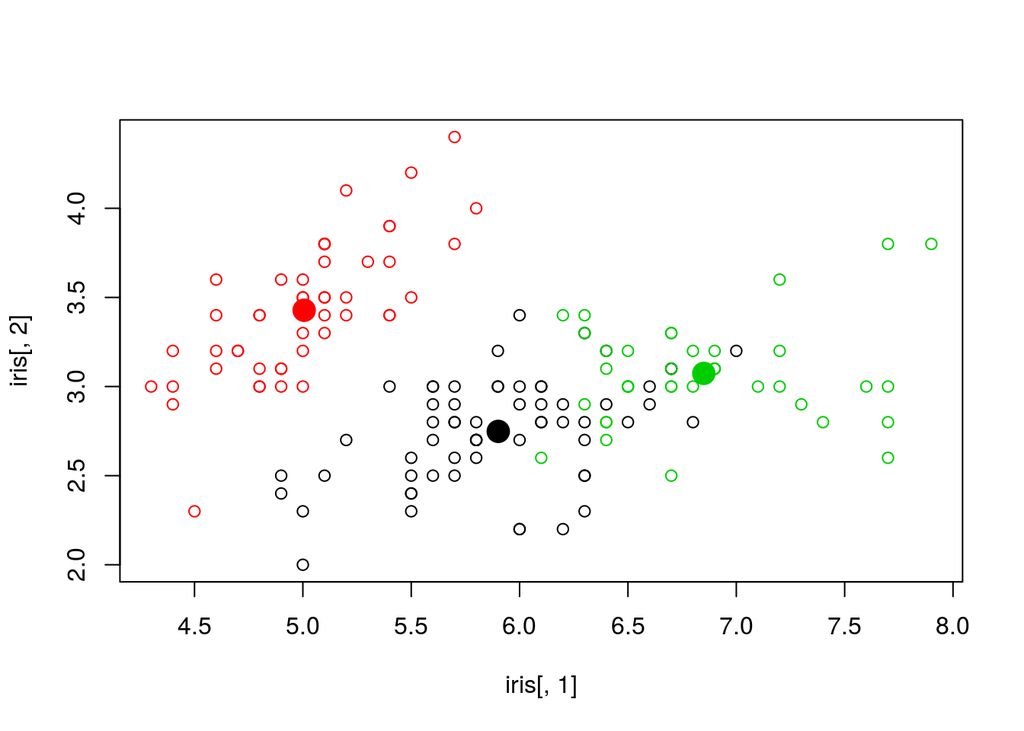

```r
library(stats)
set.seed(101)
km <- kmeans(iris[,1:4], 3)
plot(iris[,1], iris[,2], col=km$cluster)
points(km$centers[,c(1,2)], col=1:3, pch=19, cex=2)
```

```r
table(km$cluster, iris$Species)
```

```
##
##     setosa versicolor virginica
##   1      0         48        14
##   2     50          0         0
##   3      0          2        36
```

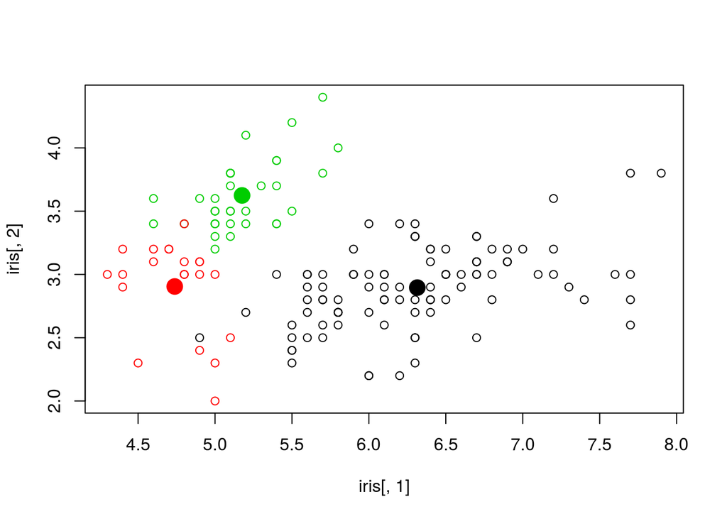

```r
set.seed(900)
km <- kmeans(iris[,1:4], 3)
plot(iris[,1], iris[,2], col=km$cluster)
points(km$centers[,c(1,2)], col=1:3, pch=19, cex=2)
```

```r
table(predicted=km$cluster, true=iris$Species)
```

```
##          true
## predicted setosa versicolor virginica
##         1      0         46        50
##         2     17          4         0
##         3     33          0         0
```

### I-b) *Clustering* jerárquico

En este enfoque, se comparan todos los pares de puntos de datos y se agrupan de acuerdo al que tenga la distancia más cercana.

**Pasos:**

1. Calculamos la distancia entre cada par de puntos,
   $$\{d(x_i,x_j):i,j=1,\ldots,n \text{ con }i\neq j\}$$
   **Notas:**
1. La distancia entre el punto es sólo el uso de la función de distancia.
2. El cálculo de la distancia entre el punto $x$ al grupo $C$ puede implicar muchas opciones (como la distancia min / max / avg entre el punto $x$ y los puntos en el grupo $C$).
3. El cálculo de la distancia entre $C_k$ y $C_l$ se puede calcular como la distancia de todos los pares de puntos (uno-a-uno) y, a continuación, eligiendo min / max / avg de estos pares.
2. Agrupamos los dos puntos más cercanos en un grupo. Volvemos a (1) hasta que sólo queda un grupo grande.

En la agrupación jerárquica, la complejidad computacional es $O(n^2)$, la salida será un árbol de etapas de agrupación.

**Nota:** No se requiere que especifiquemos $K$ o una función media. Puesto que su alta complejidad, la agrupación jerárquica se utiliza típicamente cuando el número de puntos no es demasiado alto.

```r
m <- matrix(1:15,5,3)
dist(m)
```

```
##          1        2        3        4
## 2 1.732051
## 3 3.464102 1.732051
## 4 5.196152 3.464102 1.732051
## 5 6.928203 5.196152 3.464102 1.732051
```

```r
# Calcula la distancia entre filas de m (ya que hay 3 columnas, es la distancia euclidiana entre puntos tridimensionales)
dist(m,method="manhattan")
```

```
##    1  2  3  4
## 2  3
## 3  6  3
## 4  9  6  3
## 5 12  9  6  3
```

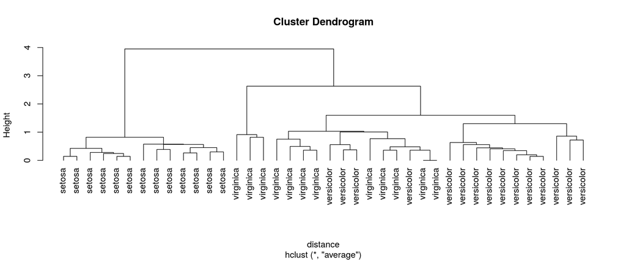

```r
# Usando la métrica de manhattan
set.seed(101)
sampleiris <- iris[sample(1:150, 40),]
# Obtener muestras del conjunto de datos del iris
# Cada observación tiene 4 variables, es decir, se interpretan como puntos 4-D
distance   <- dist(sampleiris[,-5], method="euclidean")
cluster    <- hclust(distance, method="average")
plot(cluster, hang=-1, label=sampleiris$Species)
```

Pesentacion alternativa de la inforacion:

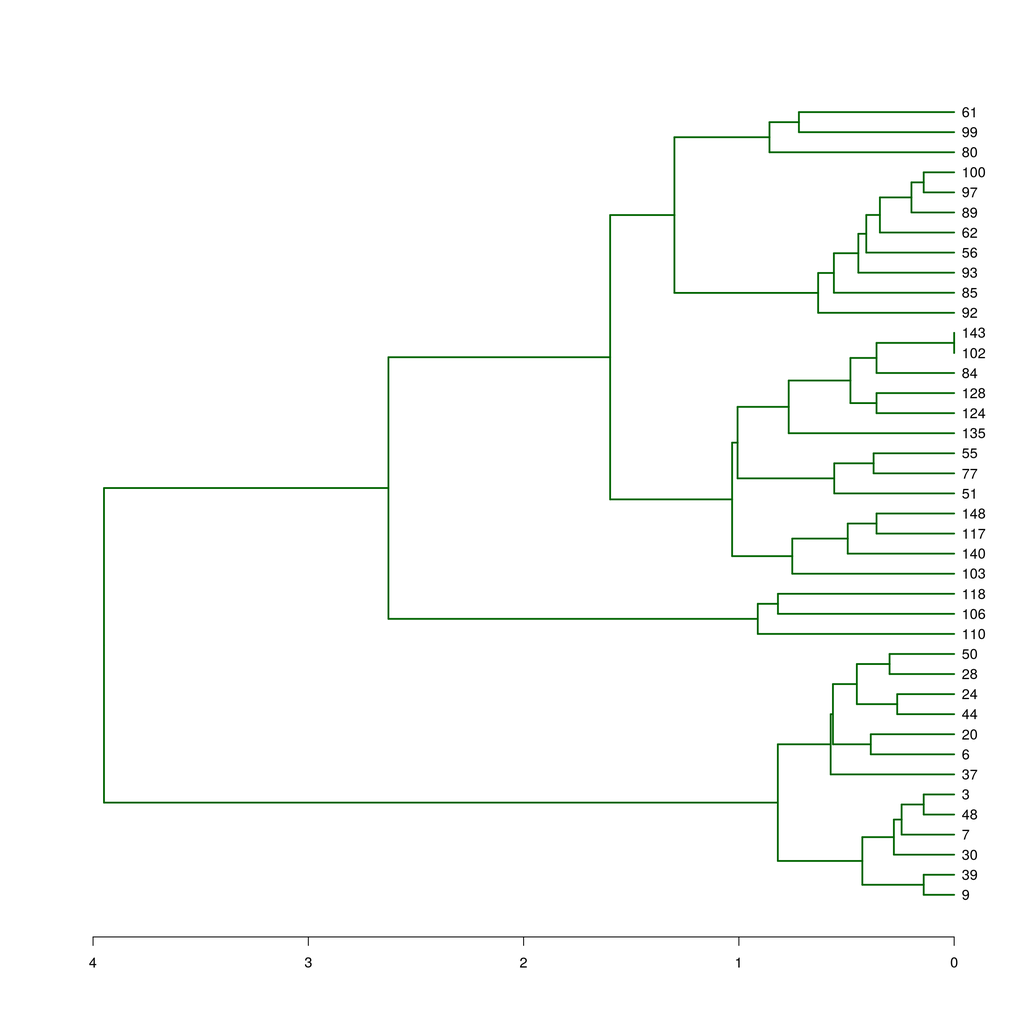

```r
plot(as.dendrogram(cluster), edgePar=list(col="darkgreen", lwd=2), horiz=T)
```

```r
str(as.dendrogram(cluster))
```

```
## --[dendrogram w/ 2 branches and 40 members at h = 3.95]
##   |--[dendrogram w/ 2 branches and 13 members at h = 0.819]
##   |  |--[dendrogram w/ 2 branches and 6 members at h = 0.426]
##   |  |  |--[dendrogram w/ 2 branches and 2 members at h = 0.141]
##   |  |  |  |--leaf "9"
##   |  |  |  `--leaf "39"
##   |  |  `--[dendrogram w/ 2 branches and 4 members at h = 0.28]
##   |  |     |--leaf "30"
##   |  |     `--[dendrogram w/ 2 branches and 3 members at h = 0.244]
##   |  |        |--leaf "7"
##   |  |        `--[dendrogram w/ 2 branches and 2 members at h = 0.141]
##   |  |           |--leaf "48"
##   |  |           `--leaf "3"
##   |  `--[dendrogram w/ 2 branches and 7 members at h = 0.574]
##   |     |--leaf "37"
##   |     `--[dendrogram w/ 2 branches and 6 members at h = 0.563]
##   |        |--[dendrogram w/ 2 branches and 2 members at h = 0.387]
##   |        |  |--leaf "6"
##   |        |  `--leaf "20"
##   |        `--[dendrogram w/ 2 branches and 4 members at h = 0.452]
##   |           |--[dendrogram w/ 2 branches and 2 members at h = 0.265]
##   |           |  |--leaf "44"
##   |           |  `--leaf "24"
##   |           `--[dendrogram w/ 2 branches and 2 members at h = 0.3]
##   |              |--leaf "28"
##   |              `--leaf "50"
##   `--[dendrogram w/ 2 branches and 27 members at h = 2.63]
##      |--[dendrogram w/ 2 branches and 3 members at h = 0.912]
##      |  |--leaf "110"
##      |  `--[dendrogram w/ 2 branches and 2 members at h = 0.819]
##      |     |--leaf "106"
##      |     `--leaf "118"
##      `--[dendrogram w/ 2 branches and 24 members at h = 1.6]
##         |--[dendrogram w/ 2 branches and 13 members at h = 1.03]
##         |  |--[dendrogram w/ 2 branches and 4 members at h = 0.752]
##         |  |  |--leaf "103"
##         |  |  `--[dendrogram w/ 2 branches and 3 members at h = 0.494]
##         |  |     |--leaf "140"
##         |  |     `--[dendrogram w/ 2 branches and 2 members at h = 0.361]
##         |  |        |--leaf "117"
```

[output cut: 24 more lines]

```
##            |        |--leaf "93"
##            |        `--[dendrogram w/ 2 branches and 5 members at h = 0.408]
##            |           |--leaf "56"
##            |           `--[dendrogram w/ 2 branches and 4 members at h = 0.345]
##            |              |--leaf "62"
##            |              `--[dendrogram w/ 2 branches and 3 members at h = 0.198]
##            |                 |--leaf "89"
##            |                 `--[dendrogram w/ 2 branches and 2 members at h = 0.141]
##            |                    |--leaf "97"
##            |                    `--leaf "100"
##            `--[dendrogram w/ 2 branches and 3 members at h = 0.858]
##               |--leaf "80"
##               `--[dendrogram w/ 2 branches and 2 members at h = 0.721]
##                  |--leaf "99"
##                  `--leaf "61"
```

```r
# Como texto
cluster$labels[cluster$order]
```

```
##  [1] "9"   "39"  "30"  "7"   "48"  "3"   "37"  "6"   "20"  "44"  "24"
## [12] "28"  "50"  "110" "106" "118" "103" "140" "117" "148" "51"  "77"
## [23] "55"  "135" "124" "128" "84"  "102" "143" "92"  "85"  "93"  "56"
## [34] "62"  "89"  "97"  "100" "80"  "99"  "61"
```

```r
# Nieveles ene l arbol de clasifiacion
```

Truncamos ahora el numero de `clusters`:

```r
par(mfrow=c(1,2))
group.3 <- cutree(cluster, k = 3)
# 3 clusters
table(group.3, sampleiris$Species)
```

```
##
## group.3 setosa versicolor virginica
##       1      0         15         9
##       2     13          0         0
##       3      0          0         3
```

```r
# comparacion con las clases conocidas
plot(sampleiris[,c(1,2)], col=group.3, pch=19, cex=2.5, main="3 clusters")
points(sampleiris[,c(1,2)], col=sampleiris$Species, pch=19, cex=1)
group.6 <- cutree(cluster, k = 6)
# mas clusters
table(group.6, sampleiris$Species)
```

```
##
## group.6 setosa versicolor virginica
##       1      0          8         0
##       2     13          0         0
##       3      0          0         3
##       4      0          4         5
##       5      0          3         0
##       6      0          0         4
```

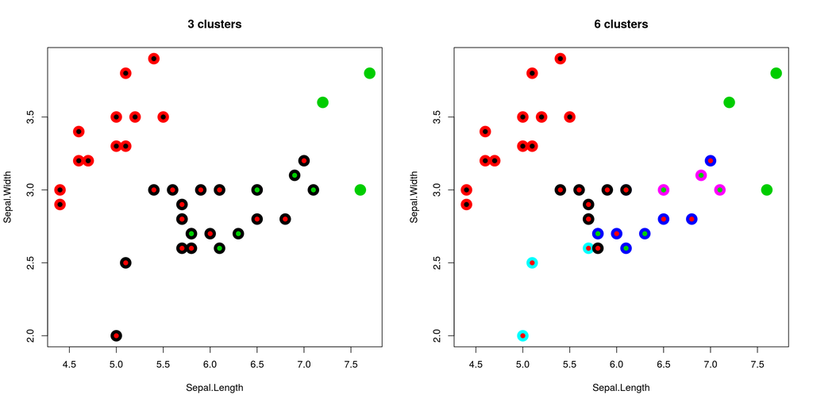

```r
plot(sampleiris[,c(1,2)], col=group.6, pch=19, cex=2.5, main="6 clusters")
points(sampleiris[,c(1,2)], col=sampleiris$Species, pch=19, cex=1)
```

```r
# clases verdaderas marcadas con circulos perqueños
par(mfrow=c(1,1))
```

Trabajando de nuevo con el arcbol original:

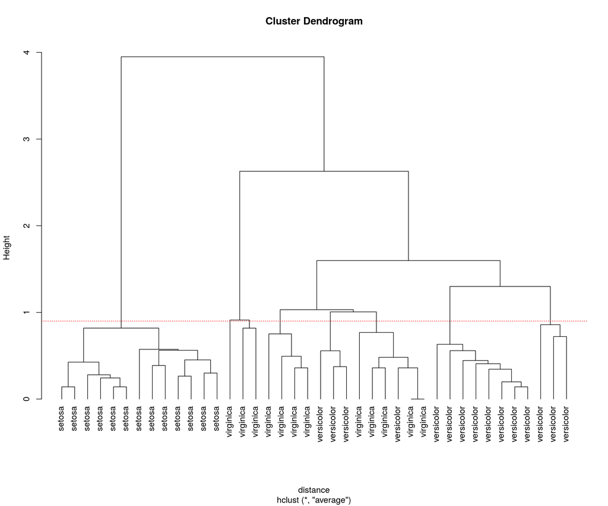

```r
plot(cluster, hang=-1, label=sampleiris$Species)
abline(h=0.9,lty=3,col="red")
```

```r
height.0.9 <- cutree(cluster, h = 0.9)
table(height.0.9, sampleiris$Species)
```

```
##
## height.0.9 setosa versicolor virginica
##          1      0          8         0
##          2     13          0         0
##          3      0          0         2
##          4      0          3         0
##          5      0          1         5
##          6      0          3         0
##          7      0          0         1
##          8      0          0         4
```

[figure not shown]

```r
# comparación con las clases verdaderas
plot(sampleiris[,c(1,2)], col=height.0.9, pch=19, cex=2.5, main="3 clusters")
points(sampleiris[,c(1,2)], col=sampleiris$Species, pch=19, cex=1)
```

#### Caso, desconocimiento del numero de clusters $K$

```r
# Disimilaridad con la distancia euclideana
dist.iris <- dist(iris, method="euclidean")
# Clustering jerarquico usando la matriz de disimilaridades
h.iris <- hclust(dist.iris, method="complete")
h.iris
```

```
##
## Call:
## hclust(d = dist.iris, method = "complete")
##
## Cluster method   : complete
## Distance         : euclidean
## Number of objects: 150
```

```r
head(h.iris$merge, n=10)
```

```
##       [,1] [,2]
##  [1,] -102 -143
##  [2,]   -8  -40
##  [3,]   -1  -18
##  [4,]  -10  -35
##  [5,] -129 -133
##  [6,]  -11  -49
##  [7,]   -5  -38
##  [8,]  -20  -22
##  [9,]  -30  -31
## [10,]  -58  -94
```

El menos enfrente del número de unidad indica que se trata de una sola observación que se está fusionando; mientras que los números por sí solos indican el paso en el cual se construyeron los grupos considerados.

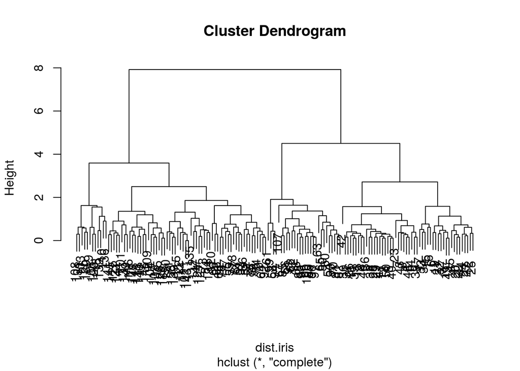

```r
plot(h.iris)
```

**¿Cuál es el número apropiado de grupos?**

Una opción común es cortar el árbol por la mayor diferencia de alturas entre dos nodos. Los valores de altura están contenidos en la salida de la función hclust:

```r
h.iris.heights <- h.iris$height # height values
h.iris.heights[1:10]
```

```
##  [1] 0.0000000 0.1118034 0.1118034 0.1118034 0.1118034 0.1118034 0.1581139
##  [8] 0.1581139 0.1581139 0.1581139
```

```r
subs <- round(h.iris.heights - c(0,h.iris.heights[-length(h.iris.heights)]), 3) # subtract next height
which.max(subs)
```

```
## [1] 149
```

Puesto que el salto más grande estaba en el último paso del proceso de fusión, sugiere dos grupos (aquí, sabemos que es tres).

### I-c) $k$-vecino

Sea $s$ muestra de entrenamiento e $I$ el conjunto de observaciones ya clasificadas.

**Pasos:**

1. Calculamos la distancia entre $s$ y cada punto en $I$
2. Ordenar las distancias en orden numérico creciente y elegir los primeros $K$ elementos
3. Calculamos y devolvemos la clase más frecuente en los $K$ vecinos más próximos, opcionalmente ponderando la clase asociada a cada punto en $s$

Utilizamos el paquete `kknn`, el cual emplea la siguiente metrica:
$$d(x,y)=\Big( \sum_i |x_i - y_i|^p \Big)^{1/p}$$
es la distancia entre los vectores $x = (x_1, x_2\ldots x_n)$ y $y = (y_1, y_2\ldots y_n)$.

Observaciones:

- Cuando $p=2$ tenemos el caso particular de la distancia euclidiana, y
- cuando $p=1$ tenemos la distancia de Manhattan.

```r
library(kknn)
library(caret)
inTrain   <- createDataPartition(y=iris$Species, p=0.75, list=FALSE)
known.set <- iris[inTrain,]
test.set  <- iris[-inTrain,]

iris.kknn <- kknn(Species ~ ., known.set, test.set[,-5],
                  distance = 1, k = 7, scale = TRUE,
                  kernel = "triangular")

iris.kknn$prob[10:20,]
```

```
##       setosa versicolor virginica
##  [1,]      1  0.0000000 0.0000000
##  [2,]      1  0.0000000 0.0000000
##  [3,]      1  0.0000000 0.0000000
##  [4,]      0  0.8998531 0.1001469
##  [5,]      0  0.6430480 0.3569520
##  [6,]      0  0.2128702 0.7871298
##  [7,]      0  1.0000000 0.0000000
##  [8,]      0  1.0000000 0.0000000
##  [9,]      0  1.0000000 0.0000000
## [10,]      0  1.0000000 0.0000000
## [11,]      0  0.8976407 0.1023593
```

```r
iris.kknn$fitted.values
```

```
##  [1] setosa     setosa     setosa     setosa     setosa     setosa
##  [7] setosa     setosa     setosa     setosa     setosa     setosa
## [13] versicolor versicolor virginica  versicolor versicolor versicolor
## [19] versicolor versicolor versicolor versicolor versicolor versicolor
## [25] virginica  virginica  virginica  virginica  virginica  virginica
## [31] virginica  versicolor virginica  virginica  virginica  virginica
## Levels: setosa versicolor virginica
```

```r
table(test.set$Species, fitted(iris.kknn))
```

```
##
##              setosa versicolor virginica
##   setosa         12          0         0
##   versicolor      0         11         1
##   virginica       0          1        11
```

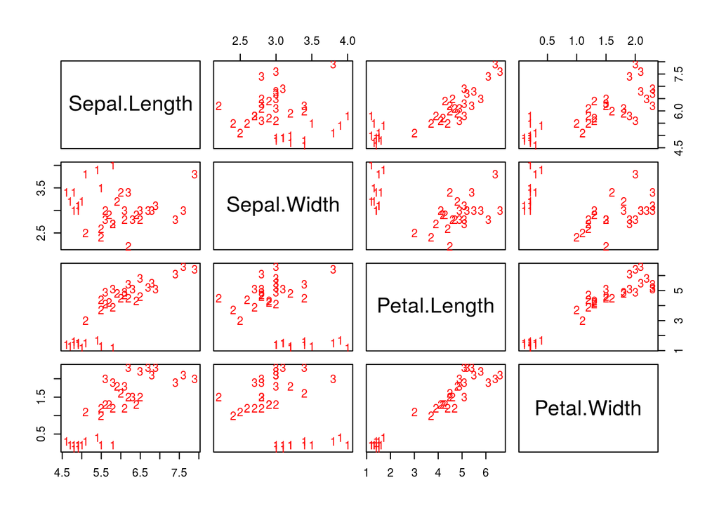

```r
pairs(test.set[,-5],
      pch = as.character(as.numeric(test.set$Species)),
      col = c("green3", "red")[(test.set$Species != iris.kknn)+1])
```

**Validacion cruzada**

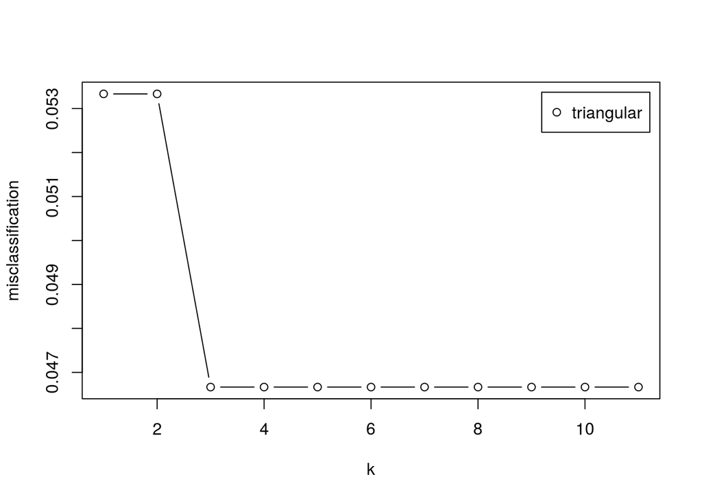

```r
set.seed(101)
iris.cv <- cv.kknn(Species ~ ., iris, kcv=10, kernel="triangular")
iris.cv
## [[1]]
##     y yhat
## 1   1    1
## 2   1    1
## 3   1    1
## 4   1    1
## 5   1    1
## 6   1    1
## 7   1    1
## 8   1    1
## 9   1    1
## 10  1    1
## 11  1    1
## 12  1    1
## 13  1    1
## 14  1    1
## 15  1    1
## 16  1    1
## 17  1    1
## 18  1    1
## 19  1    1
## 20  1    1
## 21  1    1
## 22  1    1
## 23  1    1
## 24  1    1
## 25  1    1
## 26  1    1
## 27  1    1
## 28  1    1
## 29  1    1
## 30  1    1
## 31  1    1
## 32  1    1
## 33  1    1
## 34  1    1
## 35  1    1
## 36  1    1
## 37  1    1
## 38  1    1
## 39  1    1
## 40  1    1
## 41  1    1
## 42  1    1
## 43  1    1
## 44  1    1
## 45  1    1
## 46  1    1
## 47  1    1
## 48  1    1
## 49  1    1
## 50  1    1
## 51  2    2
## 52  2    2
## 53  2    2
## 54  2    2
## 55  2    2
## 56  2    2
## 57  2    2
## 58  2    2
## 59  2    2
## 60  2    2
## 61  2    2
## 62  2    2
## 63  2    2
## 64  2    2
## 65  2    2
## 66  2    2
## 67  2    2
## 68  2    2
## 69  2    2
## 70  2    2
## 71  2    3
## 72  2    2
## 73  2    2
## 74  2    2
## 75  2    2
## 76  2    2
## 77  2    2
## 78  2    2
## 79  2    2
## 80  2    2
## 81  2    2
## 82  2    2
## 83  2    2
## 84  2    3
## 85  2    2
## 86  2    2
## 87  2    2
## 88  2    2
## 89  2    2
## 90  2    2
## 91  2    2
## 92  2    2
## 93  2    2
## 94  2    2
## 95  2    2
## 96  2    2
## 97  2    2
## 98  2    2
## 99  2    2
## 100 2    2
## 101 3    3
## 102 3    3
## 103 3    3
## 104 3    3
## 105 3    3
## 106 3    3
## 107 3    2
## 108 3    3
## 109 3    3
## 110 3    3
## 111 3    3
## 112 3    3
## 113 3    3
## 114 3    3
## 115 3    3
## 116 3    3
## 117 3    3
## 118 3    3
## 119 3    3
## 120 3    2
## 121 3    3
## 122 3    3
## 123 3    3
## 124 3    3
## 125 3    3
## 126 3    3
## 127 3    3
## 128 3    3
## 129 3    3
## 130 3    3
## 131 3    3
## 132 3    3
## 133 3    3
## 134 3    2
## 135 3    2
## 136 3    3
## 137 3    3
## 138 3    3
## 139 3    2
## 140 3    3
## 141 3    3
## 142 3    3
## 143 3    3
## 144 3    3
## 145 3    3
## 146 3    3
## 147 3    3
## 148 3    3
## 149 3    3
## 150 3    2
##
## [[2]]
## [1] 1
# Cross-validation
iris.cv2 <- train.kknn(Species ~ ., iris, nn=10, kernel="triangular")
plot(iris.cv2, type="b")
```

### I-d) *Density-based Cluster*

La clasificacion en esta tipo de asignaciones de datos se obtiene “sobre-imponiendo” una `densidad` de probabilidades.

Para esto, se definen dos parametros:

1. $r$ (o `eps`) - radio de la densidad al rededor de cada punto, y
2. `minpts` - numero de vecinos dentro del radio `eps`

El algoritmo de asignacion, conocido como `DBscan` se deifne de la siguiente forma:

1. Paso `scan` - para cada punto $x_i$ se calcula la distancia con todos los puntos restantes. Se asigna una `clase` nueva a los puntos cuya distancia sea menos que `eps`.
2. Paso `scan 2` - para cada punto, se etiqueta como un nucleo si el conteo de su vecindad es mayor que `minpts`
3. Paso `scan 3` - para cada punto, si no ha sido asignado a una `clase`, se crea una `clase` nueva y se define el `nucleo` como el punto mismo

*A diferencia de los algoritmos de asignacion anteriores, este algoritmo admite la posibilidad de identificas clases singulares (formadas por un solo dato). Estas clases son interpretadas como `outliers`.*

El algoritmo que implementa esta asignacion esta contenido en el paquete `pfc`:

```
install.packages("pfc")
```

```
library(fpc)
set.seed(121)
sampleiris <- iris[sample(1:150, 40),]
# definimos `eps`  y `MinPts`
cluster <- dbscan(sampleiris[,-5], eps=0.6, MinPts=4)
# identificamos puntos outliers (negro)
# identificamos `nucleos` (triangulos)
# identificamos puntos frontera (circulos)
plot(cluster, sampleiris)
plot(cluster, sampleiris[,c(1,4)])
# `clase` 0 son datos no clasificados en una clase
# o `clases singulares`
table(cluster$cluster, sampleiris$Species)
```

## Anexo: Escalamiento de datos

*Los algoritmos descritos en esta sesion funcionan mas eficientemente cuando los datos (escalares, desde luego) son `estandarizados por renglon` en media y varianza.*

Pensemos que tenemos un conjunto de datos $y$ que deseamos clasificar. Sera conveniente reescalarlos de la siguiente forma:

```r
# Sample data matrix.
set.seed(101)
y <- matrix(rnorm(100,20,5), 20, 5,
            dimnames=list(paste0("g", 1:20), paste0("t", 1:5)))
head(y)
```

```
##          t1       t2        t3       t4       t5
## g1 18.36982 19.18122 22.412294 18.70099 29.26074
## g2 22.76231 23.54261 23.791069 12.94413 25.55838
## g3 16.62528 18.66010  8.403363 16.79321 17.44312
## g4 21.07180 12.68039 17.702476 20.56229 17.28059
## g5 21.55385 23.72218 14.473082 22.11302 11.35536
## g6 25.86983 12.94805 22.014641 21.93418 22.35375
```

```r
apply(y,2,mean)
```

```
##       t1       t2       t3       t4       t5
## 19.51341 19.97489 18.83587 19.59978 21.14628
```

```r
apply(y,2,sd)
```

```
##       t1       t2       t3       t4       t5
## 4.333922 4.865144 4.869446 4.524513 4.896093
```

El escalamiento se obtiene con la función `scale`, la cual regresa los datos estandarizados en media y varianza.

Para escalar una matriz $m$ (o `m`) por renglones empleamos el codigo

```
m.scaled <- t(scale(t(m)))
```

```r
apply(scale(y,scale=FALSE),2,mean)
```

```
##            t1            t2            t3            t4            t5
## -1.598548e-15 -8.881784e-16  8.893168e-17  1.421073e-15  9.770179e-16
```

```r
# Escalamiento en medias
apply(scale(y,scale=FALSE),2,sd)
```

```
##       t1       t2       t3       t4       t5
## 4.333922 4.865144 4.869446 4.524513 4.896093
```

```r
yscaled.cols <- scale(y)
# escalamiento por columnas
yscaled.cols
```

```
##              t1         t2          t3           t4          t5
## g1  -0.26387079 -0.1631327  0.73446325 -0.198648360  1.65733269
## g2   0.74964351  0.7333236  1.01761146 -1.471018301  0.90114582
## g3  -0.66640154 -0.2702466 -2.14244131 -0.620301943 -0.75634973
## g4   0.35957833 -1.4993379 -0.23275522  0.212732483 -0.78954536
## g5   0.47080525  0.7702328 -0.89595069  0.555473021 -1.99974101
## g6   1.46666664 -1.4443224  0.65280043  0.515944968  0.24661813
## g7   0.82616543  0.4851763  0.82325786 -0.671623234 -0.22862037
## g8  -0.01778632 -0.1174654 -0.48594471  0.253007511  1.14253268
## g9   1.17023997  0.4853524 -0.05879892  0.024748442  0.50534193
## g10 -0.14529790  0.5171054 -1.28459287  0.005770029  1.35137610
## g11  0.71963171  0.9249059 -0.94202536  1.757031114  1.11947761
## g12 -0.80472959  0.2920519 -0.04276069  1.878634879 -0.26911410
## g13  1.75946063  1.0409647  0.83246433  1.362801669 -0.60279677
## g14 -1.57998038 -2.1254085 -1.19528556  0.002697621 -0.96957085
## g15 -0.16078505  1.2279968  1.00820991 -1.921631917  0.05387814
## g16 -0.11077790 -0.7392909 -0.84030066 -1.058014251 -1.04142430
## g17 -0.86807903  0.1778022  0.40888417  0.422738207 -0.68846829
## g18  0.17972511  0.9510079  1.39916960 -1.323790446  1.15983972
## g19 -0.83106361 -1.7127776  1.44426030  0.241333945  0.27388967
## g20 -2.25314448  0.4660622 -0.20026533  0.032114566 -1.06580171
## attr(,"scaled:center")
##       t1       t2       t3       t4       t5
## 19.51341 19.97489 18.83587 19.59978 21.14628
## attr(,"scaled:scale")
##       t1       t2       t3       t4       t5
## 4.333922 4.865144 4.869446 4.524513 4.896093
```

```r
apply(yscaled.cols, 2, mean)
```

```
##            t1            t2            t3            t4            t5
## -3.774541e-16 -1.769418e-16  2.602085e-17  3.220828e-16  1.994932e-16
```

```r
apply(yscaled.cols, 2, sd)
```

```
## t1 t2 t3 t4 t5
##  1  1  1  1  1
```

```r
yscaled.rows <- t(scale(t(y)))
# escalamiento por renglones
yscaled.rows
```

```
##              t1         t2          t3          t4         t5
## g1  -0.70146922 -0.5244426  0.18049073 -0.62921639  1.6746375
## g2   0.20805780  0.3637707  0.41335183 -1.75120706  0.7660267
## g3   0.25412664  0.7512123 -1.75440719  0.29515064  0.4539176
## g4   0.95978103 -1.5474389 -0.04691905  0.80754754 -0.1729706
## g5   0.53856095  0.9398118 -0.77173722  0.64203660 -1.3486721
## g6   1.00886709 -1.6814042  0.20622960  0.18947708  0.2768304
## g7   0.77188434  0.4958809  0.68119141 -1.60497773 -0.3439789
## g8  -0.29589986 -0.3045803 -1.07796965  0.04895326  1.6294966
## g9   1.10200904  0.2245639 -1.25282818 -0.79938451  0.7256398
## g10 -0.25023860  0.4014515 -1.38904991 -0.11614524  1.3539823
## g11 -0.08934988  0.2577665 -1.66880274  0.83705838  0.6633278
## g12 -1.05284092  0.1324959 -0.47852097  1.61227896 -0.2134129
## g13  0.95433210  0.3532205 -0.26231438  0.56122020 -1.6064584
## g14 -0.41751910 -1.2088171 -0.32626655  1.39562259  0.5569801
## g15 -0.23182819  0.9941868  0.61535180 -1.59166953  0.2139591
## g16  1.62544279  0.1005058 -0.83797717 -0.79851497 -0.0894564
## g17 -1.45035288  0.6054853  0.60022738  0.87719322 -0.6325530
## g18 -0.35271513  0.4458710  0.63996413 -1.59099957  0.8578796
## g19 -0.60885588 -1.3715211  1.16969530  0.24497448  0.5657072
## g20 -1.55574784  1.0864663  0.15982994  0.55834304 -0.2488915
## attr(,"scaled:center")
##       g1       g2       g3       g4       g5       g6       g7       g8
## 21.58501 21.71970 15.58502 17.85951 18.64350 21.02409 20.97238 20.55881
##       g9      g10      g11      g12      g13      g14      g15      g16
## 21.76062 20.26872 23.10650 20.79551 23.80567 14.26540 20.16531 16.20313
##      g17      g18      g19      g20
## 19.34120 22.19566 19.32024 17.10492
## attr(,"scaled:scale")
##       g1       g2       g3       g4       g5       g6       g7       g8
## 4.583515 5.011152 4.093492 3.346897 5.403934 4.803152 2.748557 3.793453
##       g9      g10      g11      g12      g13      g14      g15      g16
## 2.563062 5.534801 5.307861 4.530343 3.492611 3.830964 5.817778 1.741174
##      g17      g18      g19      g20
## 2.475240 5.396222 5.598357 4.728566
```

```r
apply(yscaled.rows, 1, mean)
```

```
##            g1            g2            g3            g4            g5
## -1.665335e-17 -2.942091e-16  6.661338e-17  6.938894e-18 -2.886580e-16
##            g6            g7            g8            g9           g10
##  2.775558e-17 -5.217886e-16  1.859624e-16  3.053113e-16  2.414735e-16
##           g11           g12           g13           g14           g15
##  1.387779e-16 -3.164271e-16 -4.107608e-16  1.113476e-17  2.498002e-16
##           g16           g17           g18           g19           g20
## -8.104804e-16  2.664535e-16  1.332159e-16  3.887949e-17  0.000000e+00
```

```r
apply(yscaled.rows, 1, sd)
```

```
##  g1  g2  g3  g4  g5  g6  g7  g8  g9 g10 g11 g12 g13 g14 g15 g16 g17 g18
##   1   1   1   1   1   1   1   1   1   1   1   1   1   1   1   1   1   1
## g19 g20
##   1   1
```